# Ex-9 Healthcare Analytics

09/11/2021

## Reg.no: 19BCE1160

## Name: Ashish Das

#### Analyze any healthcare related data set of your choice for handling missing values, performing data manipulation, statistical analysis, basic visualization, correlation & Regression analysis with proper inferences. Provide your submission in html format. {Do whatever analysis is applicable]

#### Pulling the dataset and the required packages.

```r
library(datarium)
library(dplyr)
```

```r
library(ggplot2)
library(caret)
mydf <- read.csv("https://raw.githubusercontent.com/Shush25/myDatasets/main/insurance.csv", na.strings = c("","?","??","???"))
mydf <- mydf[complete.cases(mydf),]
dim(mydf)
```

```
## [1] 1338    7
```

```r
str(mydf)
```

```
## 'data.frame':    1338 obs. of  7 variables:
##  $ age     : int  19 18 28 33 32 31 46 37 37 60 ...
##  $ sex     : chr  "female" "male" "male" "male" ...
##  $ bmi     : num  27.9 33.8 33 22.7 28.9 ...
##  $ children: int  0 1 3 0 0 0 1 3 2 0 ...
##  $ smoker  : chr  "yes" "no" "no" "no" ...
##  $ region  : chr  "southwest" "southeast" "southeast" "northwest" ...
##  $ charges : num  16885 1726 4449 21984 3867 ...
```

## This dataset contains various attributes such as the gender, bmi, no. of childrens, region along with the amount the person is paying as health insurance.

### Data Cleaning.

####Checking for na values.

```r
sum(is.na(mydf))
```

```
## [1] 0
```

No na values present in the dataset.

#### Checking whether the columns require furhter cleaning.

```r
unique(mydf$sex)
```

```
## [1] "female" "male"
```

```r
unique(mydf$region)
```

```
## [1] "southwest" "southeast" "northwest" "northeast"
```

```r
unique(mydf$smoker)
```

```
## [1] "yes" "no"
```

We can conclude that the columns sex, smoker and region do not require further cleaning any further cleaning and all the other columns are already in the numerical/ integer format.

### Data Visualization.

#### Bar Plot b/w number of male and female participants.

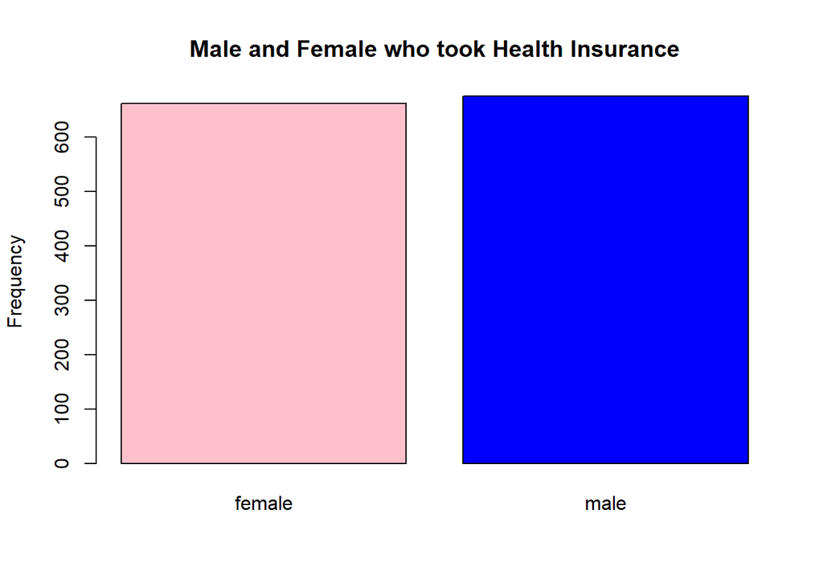

```r
barplot(table(mydf$sex),col=c("pink","blue"), main = "Male and Female who took Health Insurance", ylab = "Frequency")
```

We can infer that in our dataset the distribution of male and female who took paid the health insurance are of equal number.

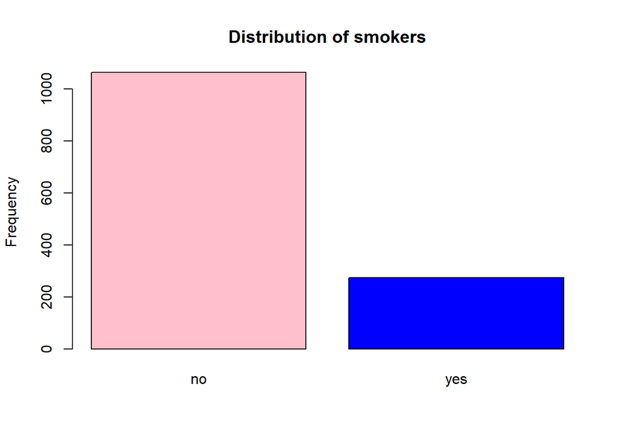

```r
barplot(table(mydf$smoker),col=c("pink","blue"), main = "Distribution of smokers", ylab = "Frequency")
```

Majority of people who have health insurance donot smoke.

#### Distribution of region using piechart

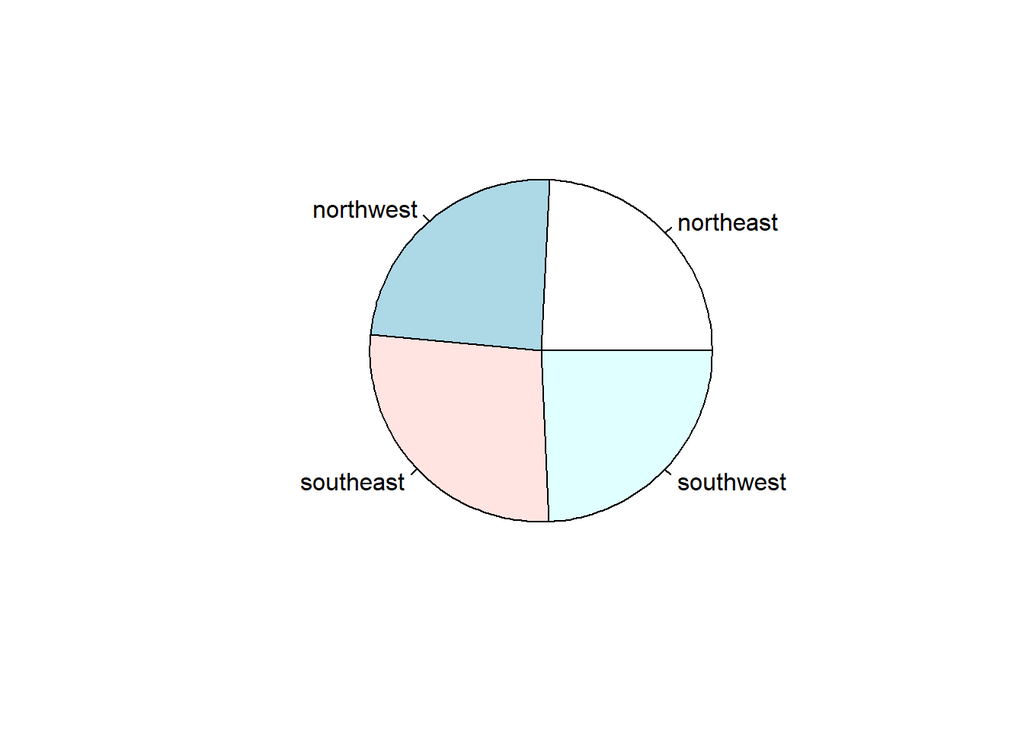

```r
pie(table(mydf$region))
```

The number of people from all the region are equally distributed this will be benificial for us when using regression to predict the cost.

#### Correlation between charges and age.

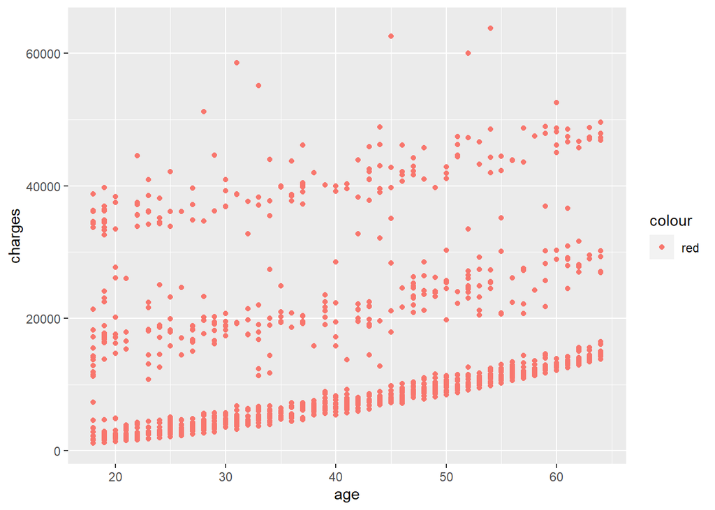

```r
ggplot(data=mydf, mapping=aes(x=age,y=charges))+geom_point(aes(color='red'))
```

We can infer that as the age increases the charges also increases

#### Correlation between charges and bmi

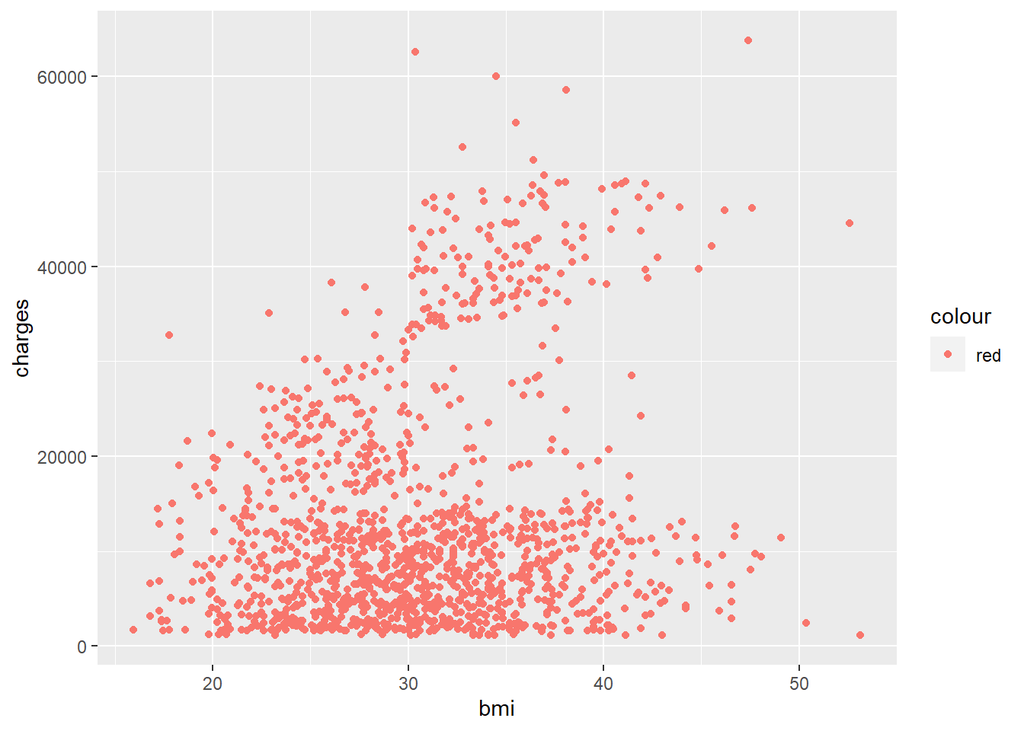

```r
ggplot(data=mydf, mapping=aes(x=bmi,y=charges))+geom_point(aes(color='red'))
```

#### Correlation between charges and number of children

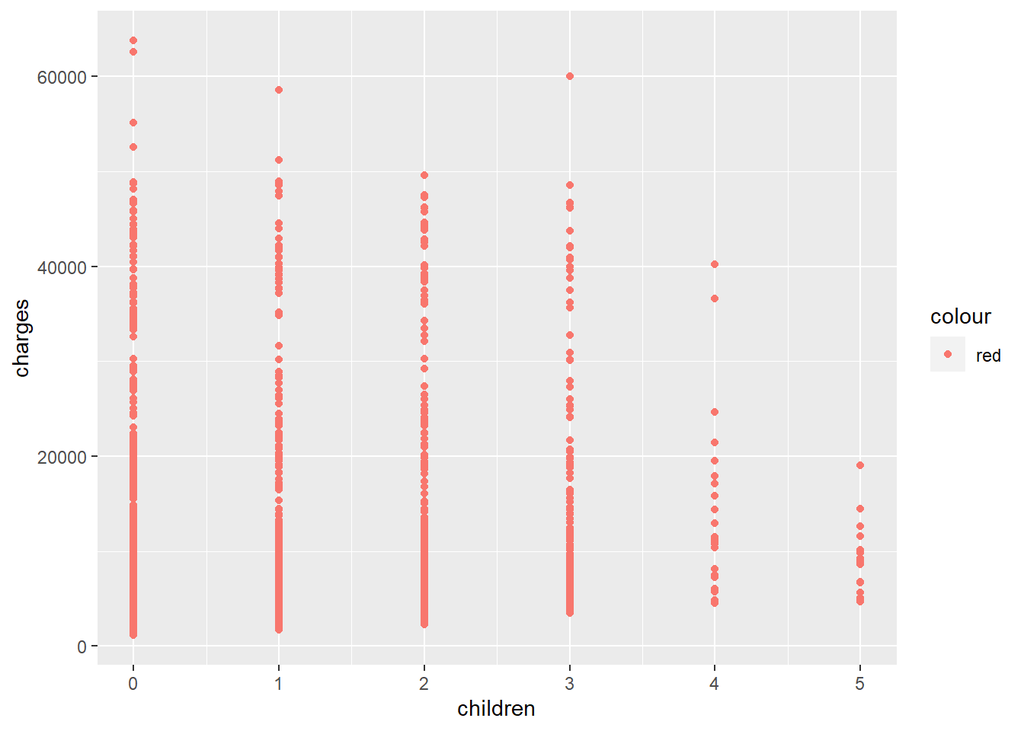

```r
ggplot(data=mydf, mapping=aes(x=children,y=charges))+geom_point(aes(color='red'))
```

#### Distribution of people taking health insurance based on there age.

```r
duration = mydf$age
range(duration)
```

```
## [1] 18 64
```

```r
breaks = seq(10,70, by = 10)
duration_cut = cut(duration, breaks, right = TRUE)
duration_freq = table(duration_cut)
cbind(duration_freq)
```

```
##         duration_freq
## (10,20]           166
## (20,30]           278
## (30,40]           257
## (40,50]           281
## (50,60]           265
## (60,70]            91
```

```r
which.max(duration_freq)
```

```
## (40,50]
##       4
```

```r
which.min(duration_freq)
```

```
## (60,70]
##       6
```

The people of age between 40-50 have the highest frequency of people who take health insurance, and those of age range 60-70 have the lowest frequency.

#### Covariance and correlation between age and charges.

```r
cov(duration, mydf$charges)
```

```
## [1] 50874.8
```

```r
cor(duration, mydf$charges)
```

```
## [1] 0.2990082
```

### Regression analysis

#### Training the multiple linear regression to predict the charge based on other parameters.

#### Data Pre processing.

```r
regdf <- mydf
regdf$sex[regdf$sex=="male"] = 1
regdf$sex[regdf$sex=="female"] = 0
regdf$sex <- as.numeric(regdf$sex)
regdf$smoker[regdf$smoker=="yes"] = 1
regdf$smoker[regdf$smoker=="no"] = 0
regdf$smoker <- as.numeric(regdf$smoker)
regdf$region[regdf$region=="southwest"] = 1
regdf$region[regdf$region=="southeast"] = 2
regdf$region[regdf$region=="northwest"] = 3
regdf$region[regdf$region=="northeast"] = 4
regdf$region <- as.numeric(regdf$region)
unique(regdf$region)
```

```
## [1] 1 2 3 4
```

Changed all the classification column to numerical columns before training the multiple-regression so as to train a better model.

#### Making training and test data

```r
set.seed(123)
train_samples <- regdf$charges %>%
  createDataPartition(p=0.8,list=FALSE)
head(train_samples)
```

```
##      Resample1
## [1,]         1
## [2,]         2
## [3,]         3
## [4,]         4
## [5,]         6
## [6,]         7
```

```r
train <- regdf[train_samples,]
test <- regdf[-train_samples,]
```

#### Summary of our model

```r
model <- lm(charges~.,data=train)
summary(model)
```

```
##
## Call:
## lm(formula = charges ~ ., data = train)
##
## Residuals:
##      Min       1Q   Median       3Q      Max
## -11635.7  -2698.4   -943.3   1407.7  29460.6
##
## Coefficients:
##              Estimate Std. Error t value Pr(>|t|)
## (Intercept) -12668.88    1190.84 -10.639  < 2e-16 ***
## age            247.38      13.22  18.717  < 2e-16 ***
## sex           -117.36     368.55  -0.318  0.75022
## bmi            324.05      30.78  10.527  < 2e-16 ***
## children       438.31     153.91   2.848  0.00449 **
## smoker       24227.91     454.13  53.350  < 2e-16 ***
## region         360.25     169.90   2.120  0.03421 *
## ---
## Signif. codes:  0 '***' 0.001 '**' 0.01 '*' 0.05 '.' 0.1 ' ' 1
##
## Residual standard error: 6006 on 1065 degrees of freedom
## Multiple R-squared:  0.7593, Adjusted R-squared:  0.7579
## F-statistic: 559.9 on 6 and 1065 DF,  p-value: < 2.2e-16
```

All Values of Pr(>|t|) is less than .05 except the sex column so removing the sex column and training the model again. F-Statistic is 559.9 which is high the higher the better

```r
regdf <- subset(regdf, select=-c(sex))
str(regdf)
```

```
## 'data.frame':    1338 obs. of  6 variables:
##  $ age     : int  19 18 28 33 32 31 46 37 37 60 ...
##  $ bmi     : num  27.9 33.8 33 22.7 28.9 ...
##  $ children: int  0 1 3 0 0 0 1 3 2 0 ...
##  $ smoker  : num  1 0 0 0 0 0 0 0 0 0 ...
##  $ region  : num  1 2 2 3 3 2 2 3 4 3 ...
##  $ charges : num  16885 1726 4449 21984 3867 ...
```

#### Training the model again after dropping the column sex.

```r
set.seed(123)
train_samples <- regdf$charges %>%
  createDataPartition(p=0.8,list=FALSE)
head(train_samples)
```

```
##      Resample1
## [1,]         1
## [2,]         2
## [3,]         3
## [4,]         4
## [5,]         6
## [6,]         7
```

```r
train <- regdf[train_samples,]
test <- regdf[-train_samples,]
model <- lm(charges~.,data=train)
summary(model)
```

```
##
## Call:
## lm(formula = charges ~ ., data = train)
##
## Residuals:
##      Min       1Q   Median       3Q      Max
## -11691.5  -2692.9   -927.5   1383.5  29409.8
##
## Coefficients:
##              Estimate Std. Error t value Pr(>|t|)
## (Intercept) -12714.23    1181.80 -10.758   <2e-16 ***
## age            247.50      13.21  18.743   <2e-16 ***
## bmi            323.56      30.73  10.529   <2e-16 ***
## children       437.96     153.84   2.847   0.0045 **
## smoker       24216.88     452.62  53.504   <2e-16 ***
## region         359.77     169.83   2.118   0.0344 *
## ---
## Signif. codes:  0 '***' 0.001 '**' 0.01 '*' 0.05 '.' 0.1 ' ' 1
##
## Residual standard error: 6003 on 1066 degrees of freedom
## Multiple R-squared:  0.7593, Adjusted R-squared:  0.7582
## F-statistic: 672.5 on 5 and 1066 DF,  p-value: < 2.2e-16
```

#### prediction using model

```r
pred <- model %>%
  predict(test)
```

#### Calculating the Root mean squared values

```r
RMSE <- RMSE(pred,test$charges)
RMSE
```

```
## [1] 6293.488
```

```r
R2 <- R2(pred,test$charges)
R2
```

```
## [1] 0.7127615
```

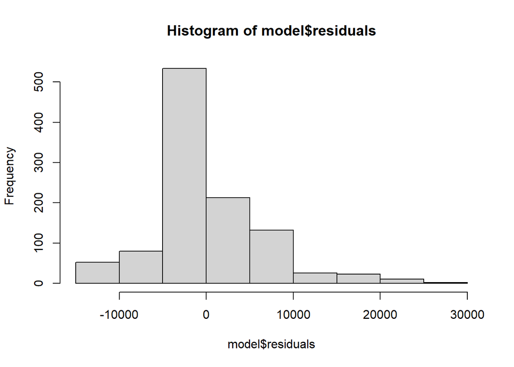

```r
hist(model$residuals)
```

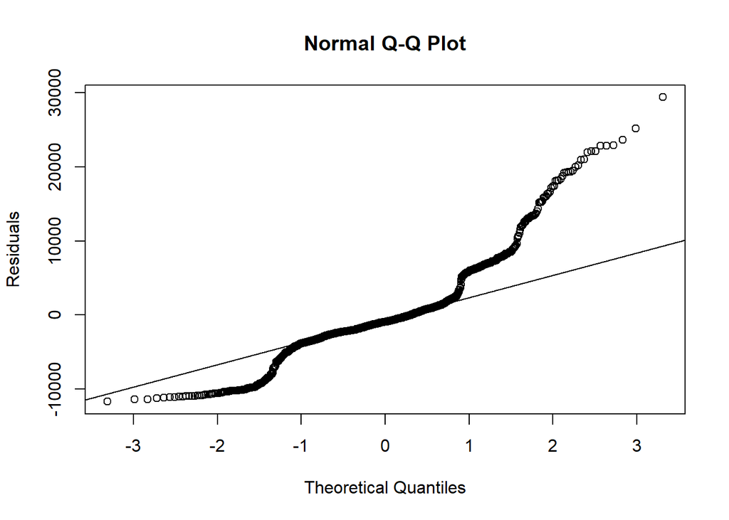

```r
qqnorm(model$residuals,ylab = "Residuals")
qqline(model$residuals)
```